# Lab 6: Team All Stars

Johnny Tamanaha, Emily Archambault, Eugene Miller, Kaiyuan Fan, Jingzhi Zhang

10/4/2019

## Overall Questions

The DIA managers want to know what policies they could enact to increase the chances of on-time (or early) arrivals.

Are more flights delayed because of the carrier, weather, NAS (National Air System, aka the air traffic controllers), security issues, or aircraft late in arriving causing delays in departures?

## Team Plots

## Team Recommendation

## Individual Sections

## Eugene Miller

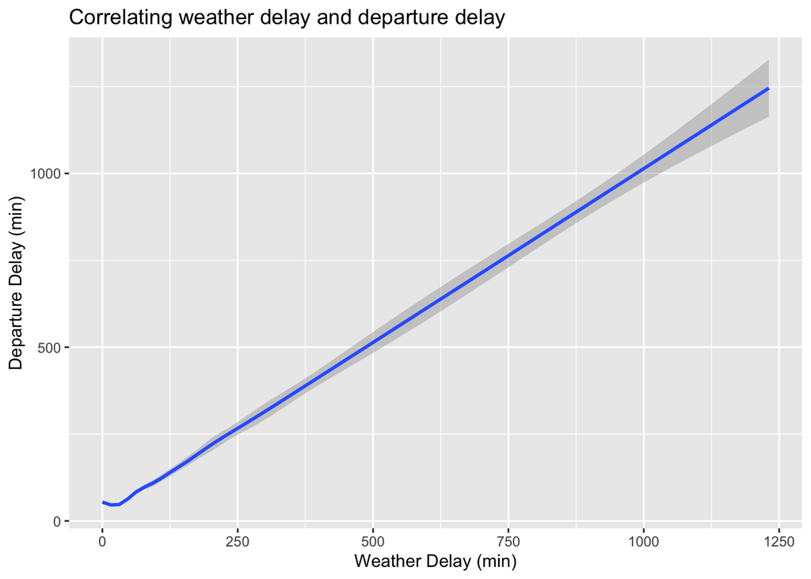

If the weather delay was at least 5 minutes, what’s the probability of a departure delay?

```r
lateAircraft <- DENflights %>%
  filter(WEATHER_DELAY > 5)
lateAircraftDepDelay <- lateAircraft %>%
  filter(DEP_DELAY >= 15)
prob <- count(lateAircraftDepDelay)/count(lateAircraft)
```

It is: 0.8929987

If a weather delay occurs then departure was more than likely delayed.

What’s the relationship between month and departure delay?

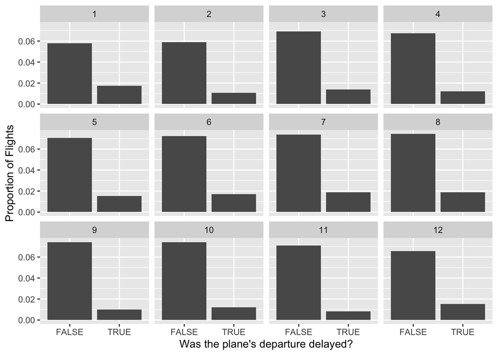

By month, whats the probability that a flight’s departure is delayed?

```r
janFlights <- DENflights %>%
  filter(MONTH == 1)
janLate <- janFlights %>%
  filter(DEP_DELAY >= 15)
janProb <- count(janLate)/count(janFlights)

junFlights <- DENflights %>%
  filter(MONTH == 6)
junLate <- junFlights %>%
  filter(DEP_DELAY >= 15)
junProb <- count(junLate)/count(junFlights)

octFlights <- DENflights %>%
  filter(MONTH == 10)
octLate <- octFlights %>%
  filter(DEP_DELAY >= 15)
octProb <- count(octLate)/count(octFlights)
```

January: 0.2309234

June: 0.1918848

October: 0.1409371

This suggest that time of year can vary the likelyhood that a departure delay occurs significantly.

## Emily Archambault

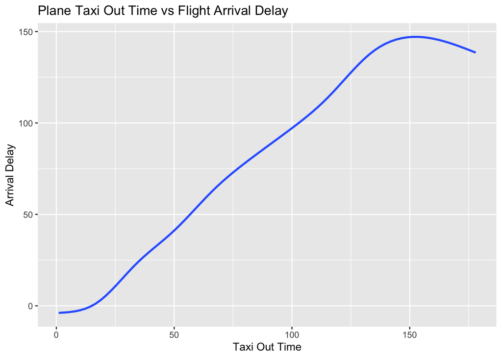

Probability of a Flight Arriving Late, Given that it Had a Taxi Out Time >15 Mins:

```r
taxiandlate <- DENVflights %>% filter(ARR_DELAY >= 15, TAXI_OUT >= 15) %>% filter(!is.na(ARR_TIME)) %>% count()
taxilate <- DENVflights %>% filter(TAXI_OUT >= 15) %>% filter(!is.na(ARR_TIME)) %>% count()
prob <- taxiandlate/taxilate
```

probability = 0.2216605 The plot and probability suggest there is a strong correlation between the length of time a plane spends taxi-ing out and the amount the arrival is delayed.

##Arrival Delay vs Month

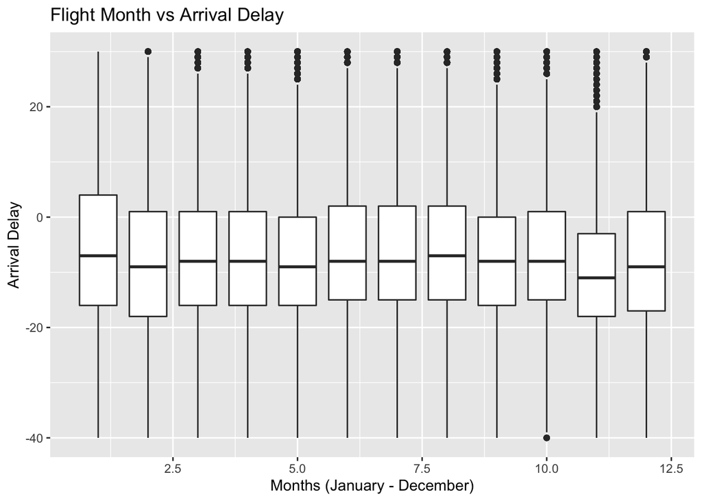

Probability of a Flight Arriving Late, Given That it was in January

```r
janlate <- DENVflights %>% filter(ARR_DELAY >= 15, MONTH == 1) %>% filter(!is.na(ARR_TIME)) %>% count()
janflights <- DENVflights %>% filter(MONTH == 1) %>% filter(!is.na(ARR_TIME)) %>% count()
janprob <- janlate/janflights
```

probability = 0.2472256

Probability of a Flight Arriving Late, Given That it was in November

```r
novlate <- DENVflights %>% filter(ARR_DELAY >= 15, MONTH == 11) %>% filter(!is.na(ARR_TIME)) %>% count()
novflights <- DENVflights %>% filter(MONTH == 11) %>% filter(!is.na(ARR_TIME)) %>% count()
novprob <- novlate/novflights
```

probability = 0.0934686

The plot and probabilities suggest that the month of the year has an effect on the likelihood of a flight arriving late. Some months (such as January) have a much higher probability of having late flights than others (such as November).

## Johnny Tamanaha

[figure not shown]

```r
uniq_dest <- DENflights %>%
  group_by(DEST) %>%
  summarize(total=n(), late=sum(DEP_DELAY>=15), prop=late/total) %>%
  filter(total>=200) %>%
  filter(rank(desc(prop)) < 10) %>%
  arrange(desc(prop))
ggplot(uniq_dest) +
  geom_col(mapping=aes(x=DEST, y=prop)) +
  labs(title="10 Highest Late Flight Proportions by Destination (originating from DEN)")+
  xlab("Destination")+
  ylab("Proportion of Late Flights")
```

```r
uniq_dest <- DENflights %>%
  group_by(DEST) %>%
  summarize(total=n(), late=sum(DEP_DELAY>=15), prop=late/total) %>%
  filter(total>=200) %>%
  filter(rank(desc(prop)) < 10) %>%
  arrange(desc(prop))
uniq_dest
```

```
## # A tibble: 9 x 4
##   DEST  total  late  prop
##   <chr> <int> <int> <dbl>
## 1 ALB     239   102 0.427
## 2 EWR    3575  1177 0.329
## 3 GRR     666   192 0.288
## 4 SFO    7296  2067 0.283
## 5 SDF     521   147 0.282
## 6 BDL     758   213 0.281
## 7 JAX     368    96 0.261
## 8 JFK    1355   341 0.252
## 9 LGA    3801   951 0.250
```

Albany airport’s late flight percentage is 10% greater than the second highest and 14% higher than the third highest late flight percentage. Also, Newark (at second place) is 4% higher than third place, which is significant because the next couple proportions don’t differ by more than 1%. This indicates that there may be a correlation between the destinations ALB and EWR and departure delays.

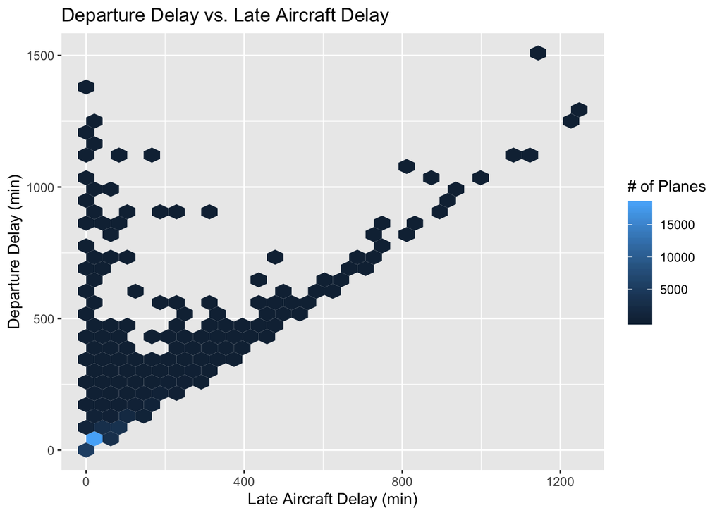

```r
late_aircraft_delay <- DENflights %>%
  filter(LATE_AIRCRAFT_DELAY>0)
ggplot(late_aircraft_delay) +
  stat_binhex(mapping=aes(x=LATE_AIRCRAFT_DELAY, y=DEP_DELAY)) +
  labs(title="Departure Delay vs. Late Aircraft Delay", fill="# of Planes") +
  xlab("Late Aircraft Delay (min)") +
  ylab("Departure Delay (min)")
```

```r
late_total<- DENflights %>%
  summarize(total=n(), late=sum(DEP_DELAY>=15), prop=late/total)
late_aircraft <- DENflights %>%
  filter(LATE_AIRCRAFT_DELAY >0) %>%
  summarize(total=n(), late=sum(DEP_DELAY>=15), prop=late/total)
```

Proportion of late flights from entire dataset: 0.1703642.

Proportion of late flights from flights with aircraft delay: 0.9299884.

Out of all the flights, 17% had departure delays that were 15 min or greater. If I filtered for flights with positive late aircraft delay (given aircraft delay greater than 0), that number jumps up to 93%. This suggests a correlation between late aircraft delay and delayed flights.

# Lab 6: Team All Stars

Johnny Tamanaha, Emily Archambault, Eugene Miller, Kaiyuan Fan, Jingzhi Zhang

10/4/2019

## Overall Questions

The DIA managers want to know what policies they could enact to increase the chances of on-time (or early) arrivals.

Are more flights delayed because of the carrier, weather, NAS (National Air System, aka the air traffic controllers), security issues, or aircraft late in arriving causing delays in departures?

## Team Plots

## Team Recommendation

## Individual Sections

## Eugene Miller

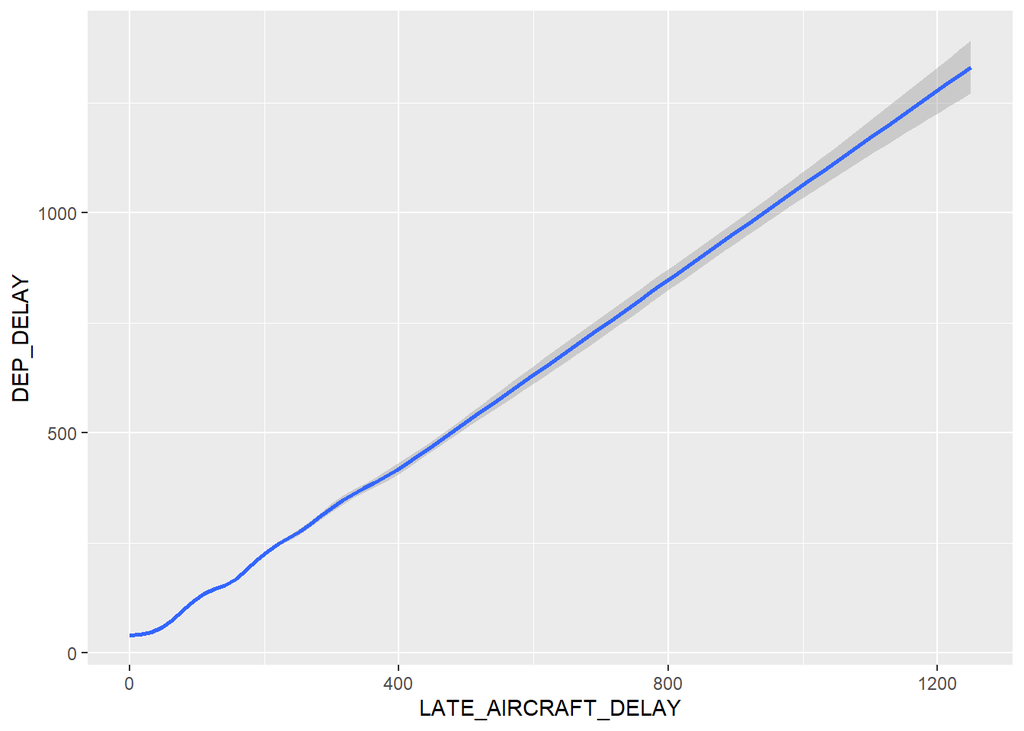

## Emily Archambault

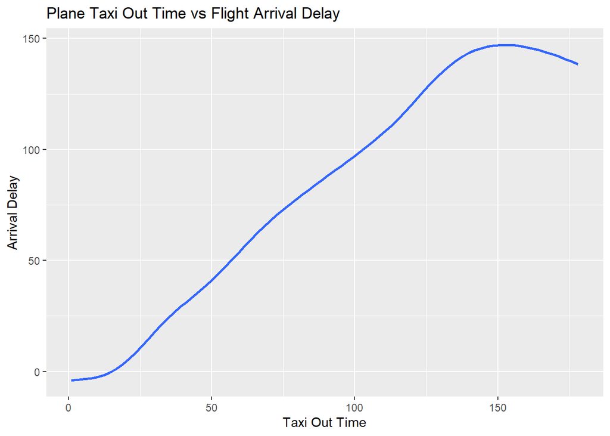

Probability of a Flight Arriving Late, Given that it Had a Taxi Out Time >15 Mins:

```r
taxiandlate <- DENVflights %>% filter(ARR_DELAY >= 15, TAXI_OUT >= 15) %>% filter(!is.na(ARR_TIME)) %>% count()
taxilate <- DENVflights %>% filter(TAXI_OUT >= 15) %>% filter(!is.na(ARR_TIME)) %>% count()
prob <- taxiandlate/taxilate
```

probability = 0.2216605 The plot and probability suggest there is a strong correlation between the length of time a plane spends taxi-ing out and the amount the arrival is delayed.

##Arrival Delay vs Month

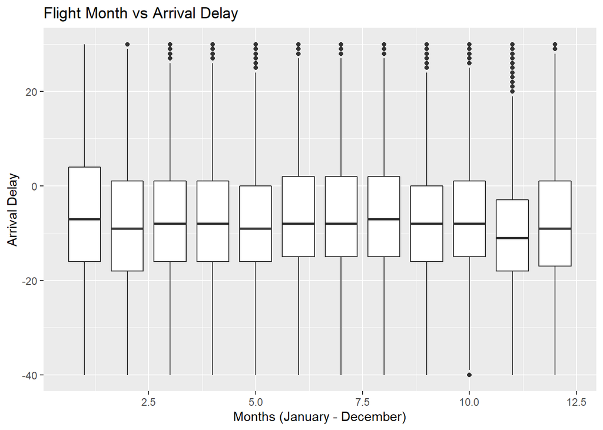

Probability of a Flight Arriving Late, Given That it was in January

```r
janlate <- DENVflights %>% filter(ARR_DELAY >= 15, MONTH == 1) %>% filter(!is.na(ARR_TIME)) %>% count()
janflights <- DENVflights %>% filter(MONTH == 1) %>% filter(!is.na(ARR_TIME)) %>% count()
janprob <- janlate/janflights
```

probability = 0.2472256

Probability of a Flight Arriving Late, Given That it was in November

```r
novlate <- DENVflights %>% filter(ARR_DELAY >= 15, MONTH == 11) %>% filter(!is.na(ARR_TIME)) %>% count()
novflights <- DENVflights %>% filter(MONTH == 11) %>% filter(!is.na(ARR_TIME)) %>% count()
novprob <- novlate/novflights
```

probability = 0.0934686

The plot and probabilities suggest that the month of the year has an effect on the likelihood of a flight arriving late. Some months (such as January) have a much higher probability of having late flights than others (such as November).

## Johnny Tamanaha

[figure not shown]

```r
uniq_dest <- DENflights %>%
  group_by(DEST) %>%
  summarize(total=n(), late=sum(DEP_DELAY>=15), prop=late/total) %>%
  filter(total>=200) %>%
  filter(rank(desc(prop)) < 10) %>%
  arrange(desc(prop))
ggplot(uniq_dest) +
  geom_col(mapping=aes(x=DEST, y=prop)) +
  labs(title="10 Highest Late Flight Proportions by Destination (originating from DEN)")+
  xlab("Destination")+
  ylab("Proportion of Late Flights")
```

```r
uniq_dest <- DENflights %>%
  group_by(DEST) %>%
  summarize(total=n(), late=sum(DEP_DELAY>=15), prop=late/total) %>%
  filter(total>=200) %>%
  filter(rank(desc(prop)) < 10) %>%
  arrange(desc(prop))
uniq_dest
```

[output not shown]

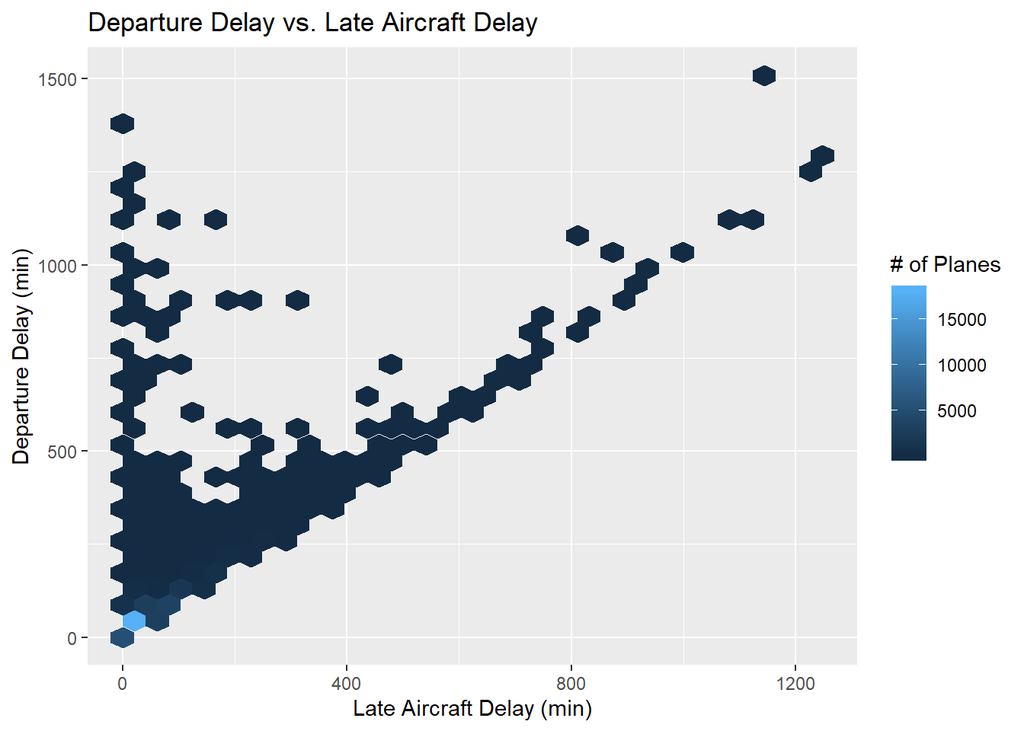

```r
late_aircraft_delay <- DENflights %>%
  filter(LATE_AIRCRAFT_DELAY>0)
ggplot(late_aircraft_delay) +
  stat_binhex(mapping=aes(x=LATE_AIRCRAFT_DELAY, y=DEP_DELAY)) +
  labs(title="Departure Delay vs. Late Aircraft Delay", fill="# of Planes") +
  xlab("Late Aircraft Delay (min)") +
  ylab("Departure Delay (min)")
```

```r
late_total<- DENflights %>%
  summarize(total=n(), late=sum(DEP_DELAY>=15), prop=late/total)
late_aircraft <- DENflights %>%
  filter(LATE_AIRCRAFT_DELAY >0) %>%
  summarize(total=n(), late=sum(DEP_DELAY>=15), prop=late/total)
```

Proportion of late flights from flights with aircraft delay: 0.9299884.